# Papers

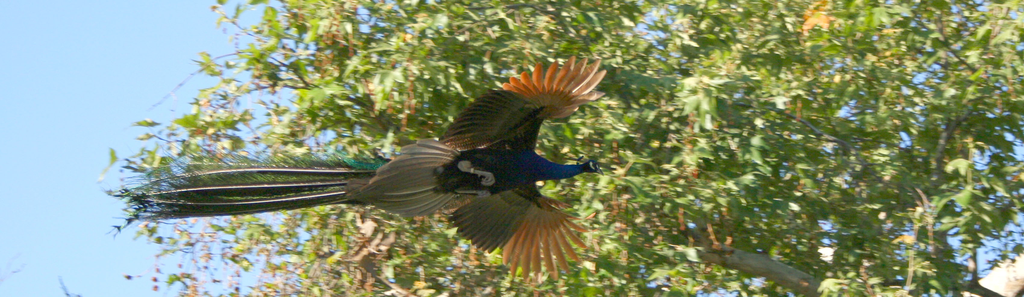

**Research Articles**

*Submitted*

JC Ríos-Orjuela, CD Cadena, A Rico-Guevara, I Berberi, L Miner, R Dakin. In revision. [Scaling and foraging behavior drive the evolution of humeral shape in hummingbirds.](https://www.biorxiv.org/content/10.1101/2025.08.11.669688v3) [biorXiv preprint]

EK Jackson and R Dakin. In review. [Migration and the excess exposure of birds to human density in North America.](https://doi.org/10.1101/2022.11.28.518244) [biorXiv preprint]

I Berberi, PS Segre, DL Altshuler, R Dakin. In revision. Unpredictable hummingbirds: [Flight path entropy is constrained by speed and wing loading.](https://www.biorxiv.org/content/10.1101/2020.08.11.246926v1) [biorXiv preprint]

EK Jackson, JA Elmore, SR Loss, BM Winger, R Dakin. In revision. [Flight morphology and visual obstruction predict collision risk in birds.](https://www.biorxiv.org/content/10.1101/2020.07.20.212985v1) [biorXiv preprint]

R Dakin, P Clunis, TB Ryder. In revision. [Reciprocal social ties drive stable cooperation within a network.](https://doi.org/10.1101/2020.11.06.371567) [biorXiv preprint]

R Dakin, TB Ryder. In revision. [Gender bias in research teams and the under-representation of women in science.](https://doi.org/10.1101/741694) [bioRxiv preprint]

*Peer-reviewed Articles*

*2025*

PS Segre, R Dakin, DL Altshuler (2025) [Turning trade-offs: hummingbird power reserves are used to decrease turning radius or increase turning velocity.](https://zslpublications.onlinelibrary.wiley.com/doi/10.1111/jzo.70014) **Journal of Zoology.** https://doi.org/10.1111/jzo.70014

E Isaksson, JJ Wijmenga, A Chaine, R Dakin, JGA Martin, KJ Mathot (2025) [Social information use increases with decreasing winter temperature in a passerine bird.](https://royalsocietypublishing.org/rsos/article/12/4/250180/235836/Social-information-use-increases-with-decreasing) **Royal Society Open Science.** https://doi.org/10.1098/rsos.250180

*2024*

VB Baliga, R Dakin, DR Wylie, DL Altshuler (2024) [Hummingbirds use distinct control strategies for forward and hovering flight.](https://doi.org/10.1098/rspb.2023.2155) **Proceedings B.** https://doi.org/10.1098/rspb.2023.2155

PE Bolton, TB Ryder, R Dakin, JL Houtz, IT Moore, CN Balakrishnan, BN Horton (2024) [Neurogenomic landscape of social status-dependent cooperative display behavior.](https://doi.org/10.1111/mec.17327) **Molecular Ecology.** https://doi.org/10.1111/mec.17327

*2023*

KM Scott, A Berberi, G Bulte, R Dakin, SJ Cooke (2023) [Freshwater turtle climbing abilities: implications for the design and use of shoreline erosion control structures.](https://doi.org/10.1016/j.ecoleng.2023.107093) **Ecological Engineering.** https://doi.org/10.1016/j.ecoleng.2023.107093

KM Scott, A Danko, P Plant, and R Dakin (2023) [What causes bird-building collision risk? Seasonal dynamics and weather drivers.](http://dx.doi.org/10.1002/ece3.9974) **Ecology and Evolution.** http://dx.doi.org/10.1002/ece3.9974

I Berberi, ET Miller, R Dakin (2023) [The effect of sociality on competitive interactions among birds.](https://doi.org/10.1098/rspb.2022.1894) **Proceedings B.** https://doi.org/10.1098/rspb.2022.1894 [[biorXiv preprint](https://doi.org/10.1101/2022.05.09.491173)]

M Fuxjager and 23 co-authors including R Dakin (2023) [Systems biology as a framework to understand the physiological and endocrine bases of behavior and its evolution—from concepts to a case study in birds.](https://doi.org/10.1016/j.yhbeh.2023.105340) **Hormones and Behavior.** https://doi.org/10.1016/j.yhbeh.2023.105340

GS Betini, E Malaj, C Donkersteeg, AC Smith, S Wilson, GW Mitchell, RG Clark, CA Bishop, LE Burns, R Dakin, C Morissey, N Mahony (2023) [Spatial variation in the association between agricultural activities and bird communities in Canada.](https://doi.org/10.1016/j.scitotenv.2023.163413) **Science of the Total Environment.** https://doi.org/10.1016/j.scitotenv.2023.163413

*2022*

DG Roche, I Berberi, F Dhane, F Lauzon, S Soeharjono, R Dakin, SA Binning (2022) [The quality of open datasets shared by researchers in ecology and evolution is moderately repeatable and slow to change.](https://royalsocietypublishing.org/doi/10.1098/rspb.2021.2780) **Proceedings B.** https://doi.org/10.1098/rspb.2021.2780

*2021*

M Campbell, R Dakin, S Stowe, K Burton, B Raven, M Mapani, JW Dawson, A Adler (2021) [Thoracic weighting of restrained subjects during exhaustion recovery causes loss of lung reserve volume in a model of police arrest.](https://doi.org/10.1038/s41598-021-94157-w) **Scientific Reports.** https://doi.org/10.1038/s41598-021-94157-w

SM Bertram, R Dakin, SJ Harrison, DT Tremblay, ML Reifer, GR Kolluru (2021) [Acoustic sigaling performance: variation in vigour at multiple scales.](https://doi.org/10.1016/j.anbehav.2021.08.001) **Animal Behaviour.** https://doi.org/10.1016/j.anbehav.2021.08.001

BJ Vernasco, R Dakin, AD Majer, MF Haussmann, TB Ryder, IT Moore (2021) [Longitudinal dynamics and behavioral correlates of telomeres in male wire-tailed manakins.](https://doi.org/10.1111/1365-2435.13715) **Functional Ecology.** https://doi.org/10.1111/1365-2435.13715

R Dakin, IT Moore, BM Horton, BJ Vernasco, TB Ryder (2021) [Testosterone-mediated behavior shapes the emergent properties of social networks.](https://besjournals.onlinelibrary.wiley.com/doi/abs/10.1111/1365-2656.13305) **Journal of Animal Ecology.** [[bioRxiv preprint](https://www.biorxiv.org/content/10.1101/737650v2.full)] https://doi.org/10.1111/1365-2656.13305

*2020*

R Dakin, PS Segre, DL Altshuler (2020) [Individual variation and the biomechanics of maneuvering flight in hummingbirds.](https://jeb.biologists.org/content/223/20/jeb161828) **Journal of Experimental Biology.** 223: jeb161828. https://doi.org/10.1242/jeb.161828

R Dakin, TB Ryder (2020) [Reciprocity and behavioral heterogeneity govern the stability of social networks.](https://www.pnas.org/content/early/2020/01/23/1913284117) **PNAS.** 117: 2993-2999. [[bioRxiv preprint](https://www.biorxiv.org/content/10.1101/694166v1)] https://doi.org/10.1073/pnas.1913284117

TB Ryder*, R Dakin*, BJ Vernasco, BS Evans, BM Horton, IT Moore (2020) [Testosterone modulates status-specific patterns of cooperation in a social network.](https://www.journals.uchicago.edu/doi/abs/10.1086/706236?af=R&mobileUi=0) **The American Naturalist.** 195: 82-94. [[bioRxiv preprint](https://www.biorxiv.org/content/10.1101/453548v3)] https://doi.org/10.1086/706236 *co-first authors

*2019*

B Goller, TK Fellows, R Dakin, LP Tyrell, E Fernandez-Juricic, DL Altshuler (2019) [Spatial and temporal resolution of the visual system of the Anna’s hummingbird (*Calypte anna*) relative to other birds.](https://www.journals.uchicago.edu/doi/abs/10.1086/705124?journalCode=pbz) **Physiological and Biochemical Zoology.** 92: 482-495. In Press. https://doi.org/10.1086/705124

SA Kane, Y Wang, R Fang, Y Lu, R Dakin (2019) [How conspicuous are peacock eyespots and other colorful feathers in the eyes of mammalian predators?](https://journals.plos.org/plosone/article?id=10.1371/journal.pone.0210924) **PLOS One.** 14: e0210924. [[bioRxiv preprint]](https://www.biorxiv.org/content/early/2019/01/07/514240) https://doi.org/10.1371/journal.pone.0210924

*2018*

R Dakin, TB Ryder (2018) [Dynamic network partnerships and social contagion drive cooperation](https://royalsocietypublishing.org/doi/full/10.1098/rspb.2018.1973). **Proceedings B.** 285: 20181973. https://doi.org/10.1098/rspb.2018.1973 [[bioRxiv preprint]](https://www.biorxiv.org/content/early/2018/11/06/430843)

R Dakin*, PS Segre*, AD Straw, DL Altshuler (2018) [Morphology, muscle capacity, skill, and maneuvering ability in hummingbirds.](http://science.sciencemag.org/content/359/6376/653) **Science.** 359: 653-657. [Cover article] https://doi.org/10.1126/science.aao7104 *co-first authors

SA Kane, D van Beveren, R Dakin (2018) [Biomechanics of the peafowl’s crest reveals frequencies tuned to social displays.](https://journals.plos.org/plosone/article?id=10.1371/journal.pone.0207247) **PLOS One**. 13: e0207247. https://doi.org/10.1371/journal.pone.0207247 [[bioRxiv preprint]](https://www.biorxiv.org/content/early/2018/10/22/197525)

*2017 – maternity leave*

*2016*

PS Segre*, R Dakin*, TG Read, AD Straw, DL Altshuler (2016) Mechanical constraints on flight at high elevation decrease maneuvering performance of hummingbirds. **Current Biology.** 26: 3368-3374. http://dx.doi.org/10.1016/j.cub.2016.10.028 *co-first authors

EE LeDue, K Mann, E Koch, B Chu, R Dakin, MD Gordon (2016) Starvation-induced depotentiation of bitter taste in *Drosophila*. **Current Biology**. 26: 2854-2861. http://dx.doi.org/10.1016/j.cub.2016.08.028

R Dakin, TK Fellows, DL Altshuler (2016) [Visual guidance of forward flight in hummingbirds reveals control based on image features instead of pattern velocity](http://www.pnas.org/content/early/2016/07/15/1603221113.full). **PNAS.** 113: 8849-8854. doi: 10.1073/pnas.1603221113 ([videos](https://www.youtube.com/playlist?list=PL-nCys3e57XohA7eZNaVa6_8ZdvRXj0Qg))

R Dakin, JQ Ouyang, ÁZ Lendvai, MF Haussmann, IT Moore, F Bonier (2016) [Weather matters: begging calls are temperature- and size-dependent signals of offspring state.](http://web.unideb.hu/~lendvai/publications/Dakin_etal_2016_Beh.pdf) **Behaviour.** 153: 871-896. https://doi.org/10.1163/1568539X-00003370

R Dakin, O McCrossan, JF Hare, R Montgomerie, SA Kane (2016) [Biomechanics of the peacock’s display: how feather structure and resonance influence multimodal signaling](http://journals.plos.org/plosone/article?id=10.1371/journal.pone.0152759). **PLOS One.** 11: e0152759. https://doi.org/10.1371/journal.pone.0152759 ([supplemental videos](https://www.youtube.com/playlist?list=PL-nCys3e57XoNS72IF8S5eUbPeX4QmEsQ))

R Dakin, ÁZ Lendvai, JQ Ouyang, IT Moore, and F Bonier (2016) [Plumage colour is associated with partner parental care in mutually ornamented tree swallows.](https://drive.google.com/file/d/131KMWdxEqVXyGXlOgOf2azLOd-EQxGYW/view?usp=drive_link) **Animal Behaviour.** 111: 111-118. https://doi.org/10.1016/j.anbehav.2015.10.006

*2015*

PS Segre, R Dakin, VB Zordan, MH Dickinson, AD Straw, DL Altshuler (2015) [Burst muscle performance predicts the speed, acceleration, and turning performance of Anna’s hummingbirds](http://elifesciences.org/content/4/e11159). **eLife.** https://doi.org/10.7554/eLife.11159

DL Altshuler, JW Bahlman, R Dakin, AH Gaede, B Goller, D Lentink, PS Segre, and DA Skandalis (2015) [The biophysics of bird flight: functional relationships integrate aerodynamics, morphology, kinematics, muscles and sensors.](https://drive.google.com/file/d/1urJr4dnjrVqnwmFpHchmQZBh8KynNGUI/view?usp=drive_link) **Canadian Journal of Zoology.** 93: 961-975. https://doi.org/10.1139/cjz-2015-0103

ÁZ Lendvai, Ç Akçay, JQ Ouyang, R Dakin, A Domalik, PS St John, M Stanback, IT Moore, and F Bonier (2015) [Analysis of the optimal duration of behavioral observations based on an automated continuous monitoring system in tree swallows (*Tachycineta bicolor*): is one hour good enough?](http://journals.plos.org/plosone/article?id=10.1371/journal.pone.0141194) **PLoS One.** 10: e0141194. [Preprint available on PeerJ](https://peerj.com/preprints/1403.pdf). https://doi.org/10.1371/journal.pone.0141194

JQ Ouyang, ÁZ Lendvai, R Dakin, A Domalik, V Fasanello, B Vassallo, MF Haussmann, IT Moore, and F Bonier (2015) [Weathering the storm: parental effort and experimental manipulation of stress hormones predict brood survival.](https://link.springer.com/article/10.1186/s12862-015-0497-8) **BMC Evolutionary Biology.** 15: 219. https://doi.org/10.1186/s12862-015-0497-8

*2014*

R Dakin and R Montgomerie (2014) [Condition-dependent mate assessment and choice by peahens: implications for sexual selection.](https://drive.google.com/file/d/1VFhAda0itlIUJcpWiNgT3n3ui5Hq-knW/view?usp=drive_link) **Behavioral Ecology.** 25: 1097-1104. https://doi.org/10.1093/beheco/aru087

R Dakin and R Montgomerie (2014) [Deceptive copulation calls attract female visitors to peacock leks.](https://drive.google.com/file/d/1O9iR9SLRk-eWakUTNerl6dCnPl22EGba/view?usp=drive_link) **American Naturalist.** 183: 558-564. https://doi.org/10.1086/675393

*2013 and earlier*

R Dakin and R Montgomerie (2013) [Eye for an eyespot: how iridescent plumage ocelli influence peacock mating success.](https://drive.google.com/file/d/1YA0nfFOigsRp0ZuFCU3XjectdWZ6AGDa/view?usp=drive_link) **Behavioral Ecology.** 24: 1048-1057 https://doi.org/10.1093/beheco/art045

R Dakin (2011) [The crest of the peafowl: a sexually dimorphic plumage ornament signals condition in both males and females](https://drive.google.com/file/d/1rk_N3Cjh4RsEyXYDdyWZLe0FAjMikgje/view?usp=drive_link). **Journal of Avian Biology.** 42: 405-414. http://dx.doi.org/10.1111/j.1600-048X.2011.05444.x

R Dakin and R Montgomerie (2011) [Peahens prefer peacocks displaying more eyespots, but rarely](https://drive.google.com/file/d/1HzrTtOVKDWQ6OJIQ1gxG6FV-pNpeN3kS/view?usp=drive_link). **Animal Behaviour.** 82: 21-28. https://doi.org/10.1016/j.anbehav.2011.03.016

R Dakin and R Montgomerie (2009) [Peacocks orient their courtship displays towards the sun](https://drive.google.com/file/d/1nSueb1oodXXU5PXBwn1ep5Oi0VEAz_oQ/view?usp=drive_link). **Behavioral Ecology and Sociobiology.** 63: 825-834. https://doi.org/10.1007/s00265-009-0717-6 ([supplementary video](http://static-content.springer.com/esm/art%3A10.1007%2Fs00265-009-0717-6/MediaObjects/265_2009_717_MOESM1_ESM.mp4))

**Data and analyses**

figshare (2023) Repository for: The effect of sociality on competitive interactions among birds. https://doi.org/10.6084/m9.figshare.19470026.v1

figshare (2020) Supplementary Materials for: *Testosterone-mediated behavior shapes the emergent properties of social networks.* https://doi.org/10.6084/m9.figshare.8321036.v1

Dryad (2019) Data from: *Testosterone modulates status-specific patterns of cooperation in a social network.* https://doi.org/10.5061/dryad.fm129s7

Dspace (2018) Dataset for: *Dynamic network partnerships and social contagion drive cooperation*. [https://repository.si.edu/handle/10088/35448](https://doi.org/10.25570/nzp/10088/35448)

figshare (2018) Statistical supplement to: *Biomechanics of the peafowl’s crest reveals frequencies tuned to social displays*. https://doi.org/10.6084/m9.figshare.5451379.v5

figshare (2017) Statistical supplement to: *Evolution reveals the biomechanical organization of maneuvering flight in hummingbirds.* doi: https://doi.org/10.6084/m9.figshare.5307136.v3

figshare (2016) Statistical supplement to: *Visual guidance of forward flight in hummingbirds reveals control based on image features instead of pattern velocity.* doi: https://doi.org/10.6084/m9.figshare.3382759.v4

figshare (2016) Statistical supplement to: *Mechanical constraints on flight at high elevation decrease maneuvering performance of hummingbirds*. doi: https://doi.org/10.6084/m9.figshare.3466361.v4

Dryad (2015) Data from: *Burst muscle performance predicts the speed, acceleration, and turning performance of Anna’s hummingbirds.* doi: http://dx.doi.org/10.5061/dryad.14762

Dryad (2013) Data from: *Deceptive copulation calls attract female visitors to peacock leks.* doi: http://dx.doi.org/10.5061/dryad.vt562

**Other published work**

[The molecular drivers of social network dynamics](https://animalecologyinfocus.com/2021/01/25/the-molecular-drivers-of-social-network-dynamics/). Invited contribution to Animal Ecology in Focus, written with Ben Vernasco. January 2021.

[Grades, the currency on campus.](https://drive.google.com/file/d/1V179kUrto-YpWPOFZm7FDAEa4BBDI9qq/view?usp=sharing) University Affairs. January 2013.

[Accreditation of environmental degree programs raises concerns.](https://drive.google.com/file/d/1fLcTgNngSE_1aeFivd_oyvK_4F9IIoLp/view?usp=sharing) University Affairs. November 2012.

Innovative, naturally. The Kingston Whig Standard and Innovation.ca. November 2011.

Dakin, PhD Thesis (2013) [Linking courtship behaviour, colour perception and mate choice decisions in peafowl.](http://qspace.library.queensu.ca/handle/1974/7857)

Dakin, MSc Thesis (2008) [The role of the visual train ornament in the courtship of peafowl, *Pavo cristatus*.](https://qspace.library.queensu.ca/handle/1974/1423)